# Study on now well exercise is performed

Ines Vidal Castiñeira

## Data cleaning

First we review sparsity, and remove rows without any informed value and columns with over 95% uninformed values (they coincide with columns that are only recorded when variable *new_window*=“yes”). Finally we exclude columns *row.names*, *X*, *user_name*, *raw_timestamp_part_1*, *raw_timestamp_part_2*, *cvtd_timestamp*, *new_window* and *num_window*, that are considered irrelevant to the experiment.

That leaves us with a smaller dataset (19622 observations and 53 variables), in principle equally relevant in modelling terms, and easier to work with in terms of performance.

We decided to keep the test dataset for final validation, and subdivide the clean training set into a training set and a test set, so that we can assess out of sample error. The table below represents the different sets:

**Table 1**: Original datasets, and sets considered for the study

|  | Original training dataset | Original testing | Clean Training dataset | Train set | Test set | Validate set |
| --- | --- | --- | --- | --- | --- | --- |
| **Observations** | 19622 | 20 | 19622 | 19585 | 37 | 20 |
| **Variables** | 160 | 160 | 53 | 53 | 53 | 53 |

## Data Exploration

Then we study how interrelated variables are (see figure below):

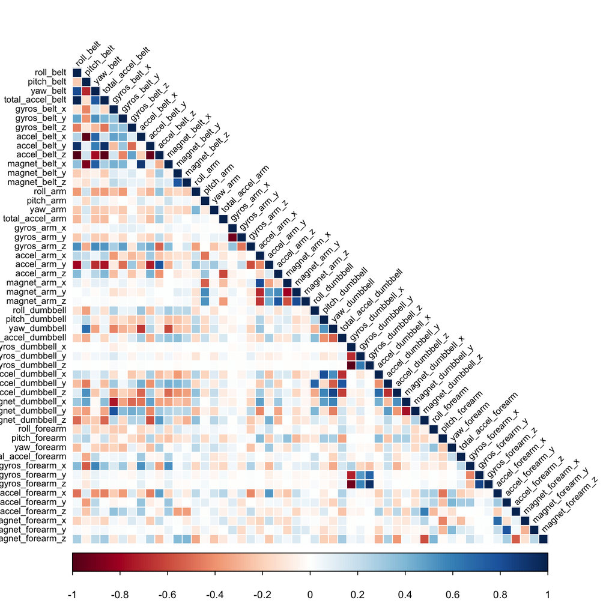

Considering the number of dark cells (high correlation), a Principal Components analysis was considered as an option to help identify the main variables to consider in the model, to reduce its complexity (and execution/training time). The negative values make a logaritmic transformation useless, so we proceed considering scaling and centering options.

```
##    user  system elapsed
##   0.035   0.002   0.038
```

```
##    user  system elapsed
##   0.018   0.000   0.018
```

```
##    user  system elapsed
##  23.994   0.693  25.836
```

```
##    user  system elapsed
##   0.015   0.000   0.014
```

```
##    user  system elapsed
##   0.026   0.001   0.026
```

```
##    user  system elapsed
##  21.009   0.461  21.629
```

```
## [1] "fit_rpart"
```

```
##    user  system elapsed
##   2.177   0.016   2.201
```

```
## [1] "fit_rf"
```

```
##    user  system elapsed
##   0.389   0.005   0.398
```

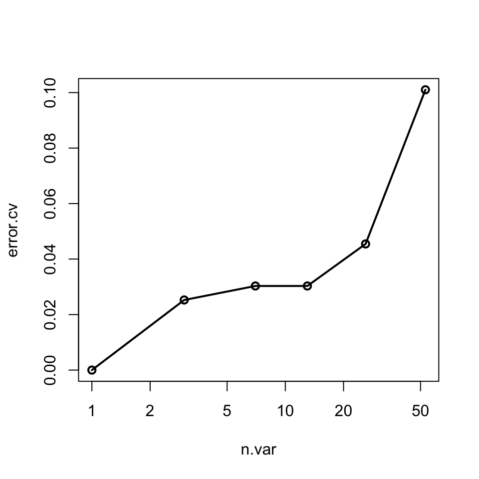

```
## [1] "fit_rf_caret con cv"
```

```
##    user  system elapsed
##  14.683   0.271  15.093
```

The following options were considered for prediction, with the associated accuracies (1% sample):

**Table 2**: Models accuracy comparison using 1% sample of ‘train set’

|  | Accuracy |
| --- | --- |
| **PCA + random forest (randomForest)** | 0.4324 |
| **PCA + random forest (caret)** | 0.6757 |
| **tree (rpart)** | 0.5135 |
| **random forest (randomForest** | 0.6757 |
| **random Forest controlling cross variance (caret)** | 0.6757 |

```
##    user  system elapsed
##  77.383   0.859  78.662
```

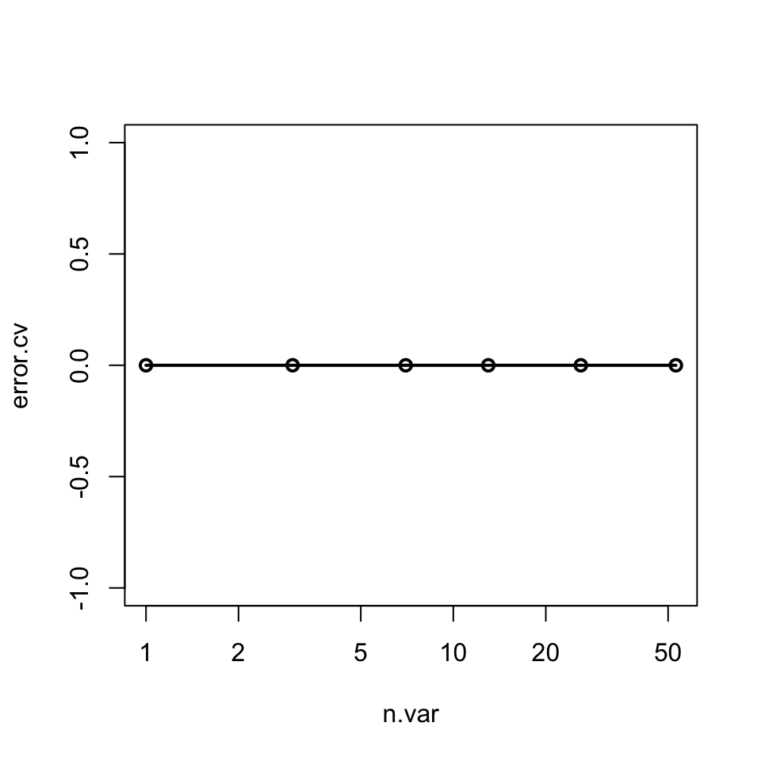

## References

In this project, your goal will be to use data from accelerometers on the belt, forearm, arm, and dumbell of 6 participants. They were asked to perform barbell lifts correctly and incorrectly in 5 different ways.

The goal of your project is to predict the manner in which they did the exercise. This is the “classe” variable in the training set. You may use any of the other variables to predict with. You should create a report describing how you built your model, how you used cross validation, what you think the expected out of sample error is, and why you made the choices you did. You will also use your prediction model to predict 20 different test cases.